# Visualizing a Single Quantitative Variable

TEMBA Statistics 2026

## A histogram counts observations in bins

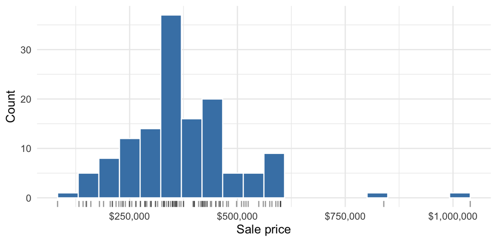

134 home sales in Austin ZIP 78752. Each tick on the baseline is one sale.

## The picture depends on the bin width

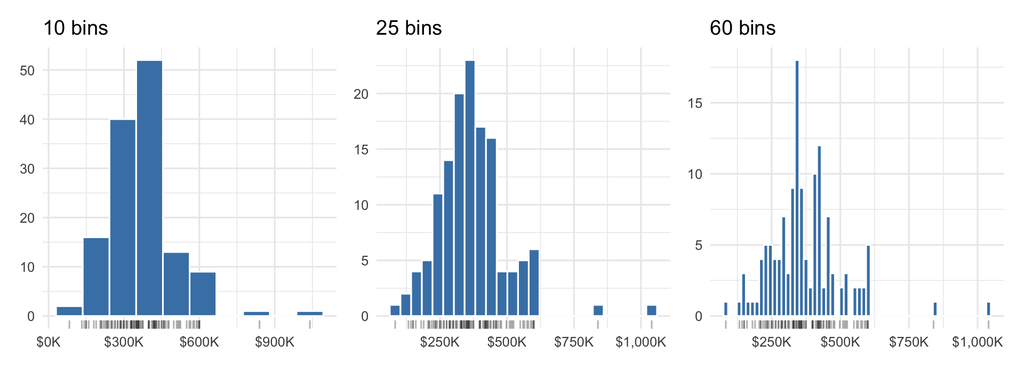

Same 134 sales in every panel.

## A density plot is a smoothed histogram

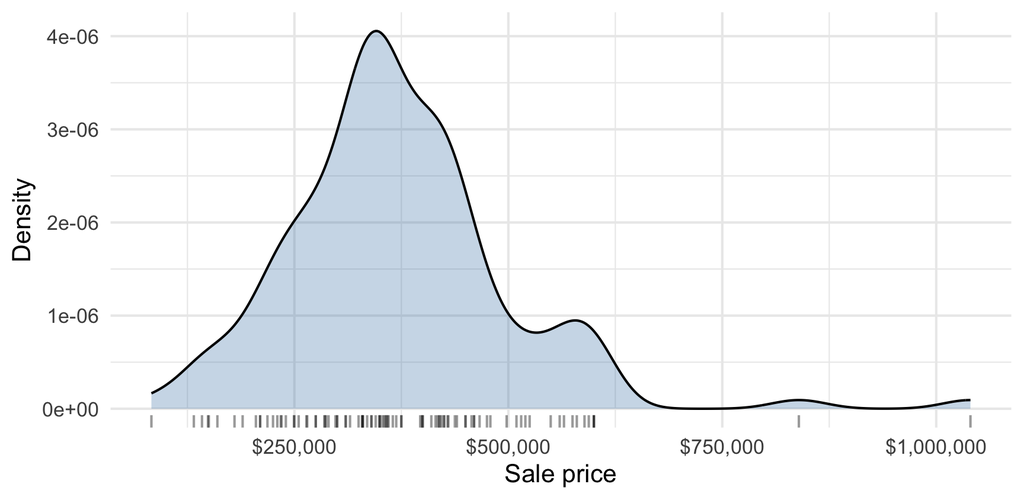

The curve is high where there are more sales close to that price.

## Areas under the curve are proportions of the data

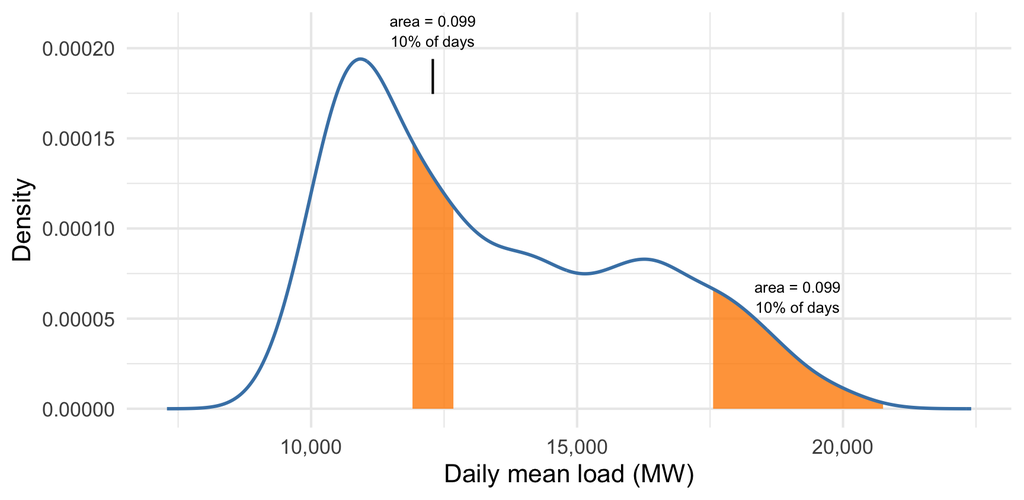

ERCOT DFW daily mean load, 2016–2020 (1,827 days): the upper interval is over four times wider for the same 10% share ([source](https://github.com/blakeshaffer/ercotproject)).

## Densities have a bandwidth instead of bins

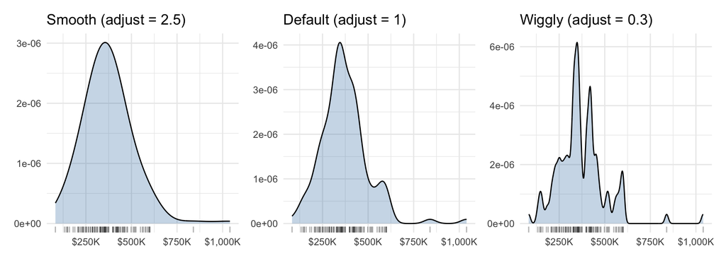

A single interpretable knob, with a default computed from the data rather than picked by hand.

## Raw counts can’t compare groups of different sizes

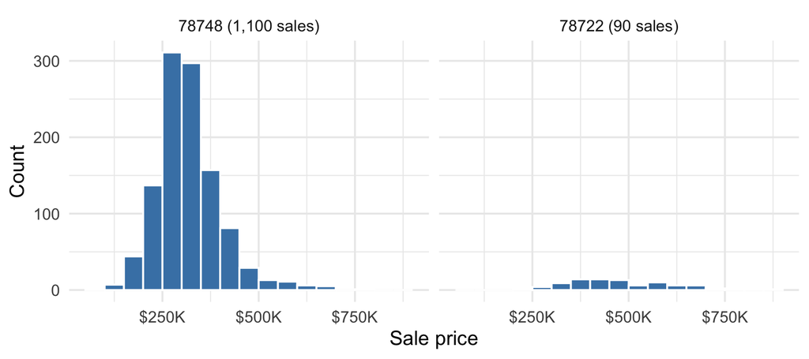

Same $50,000 bins and the same count axis, but 78748 has more than ten times as many sales as 78722, so the smaller panel is squashed flat.

## Rescaled to density, the shapes are comparable

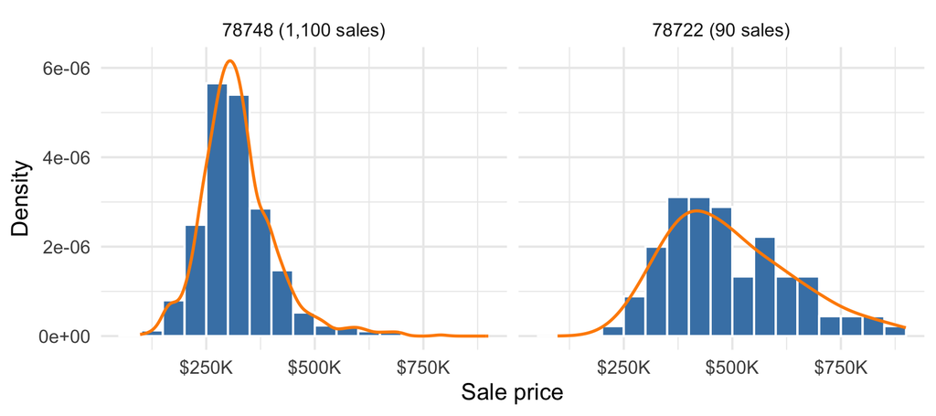

Both panels share one vertical scale: prices in 78722 sit higher and spread wider than in 78748.

## Percentiles

- Suppose you scored 655 on the GMAT Focus Edition.
- Your score report says you’re at the 90th percentile.
- That means you did at least as well as about 90% of test takers: 655 is the **90th percentile** of GMAT scores.
- In general, the **p-th percentile** is the value at or below which p% of the observations fall.

## Median, quartiles, quantiles

- The **median** is the 50th percentile: half the observations fall below it.
- The **quartiles** Q1, Q2, Q3 are the 25th, 50th, and 75th percentiles — they split the data into four equal parts.
- Written as a proportion instead of a percent, a percentile is a **quantile**: the 90th percentile is the 0.90 quantile, and the median is the 0.50 quantile.

## The empirical CDF plots every percentile at once

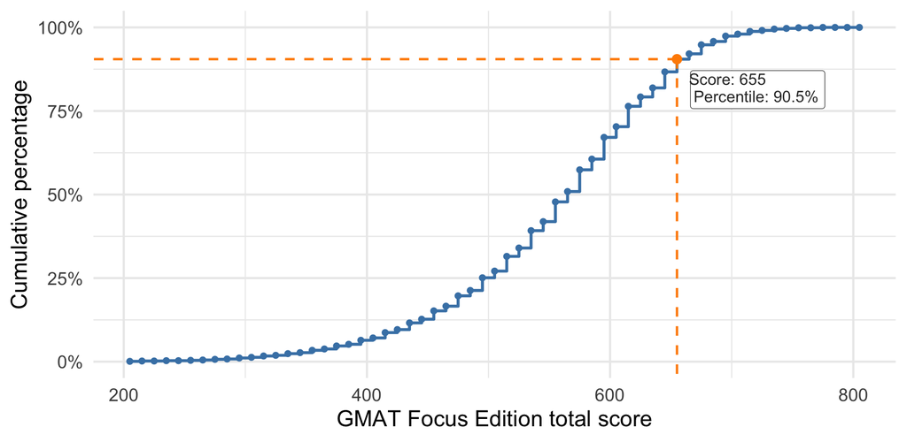

GMAC’s full concordance, 2020–2025, is one curve: the fraction of test takers at or below each score.

## The ECDF of our sale prices

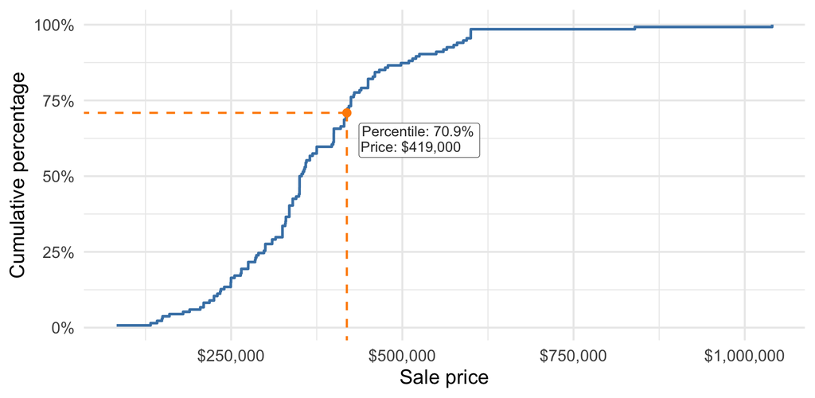

The height at each price is the fraction of sales at or below it. There are no bins or bandwidths to choose, and the quartiles read off the plot directly.

# Describing distributions

## Four things to look for

- **Location** — where is the center; what is a typical value?
- **Spread** — how far do values range from the center?
- **Skewness** — is the distribution symmetric, or stretched to one side?
- **Modality** — how many peaks are there?
- And **outliers** — observations far from the bulk of the data

## Symmetric

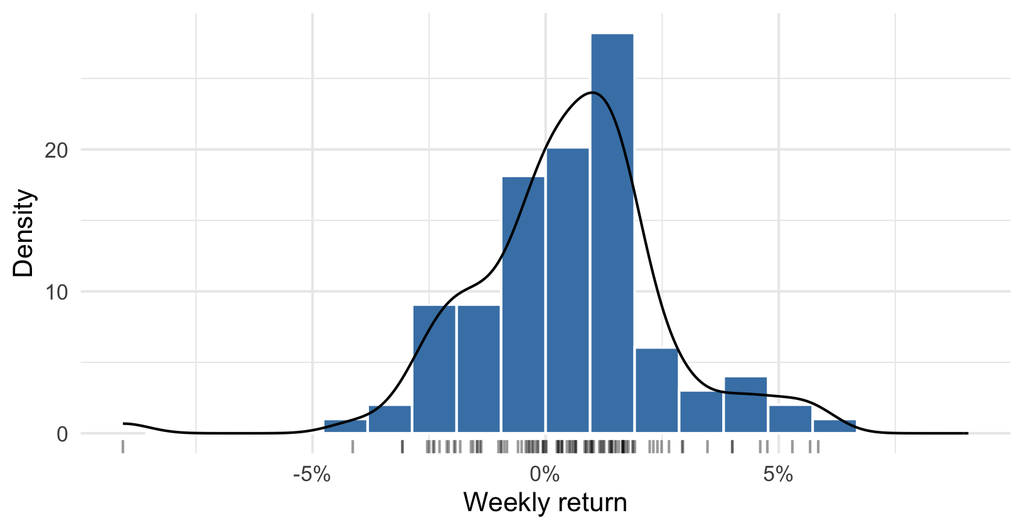

Weekly S&P 500 returns, October 2023 to September 2025: the left and right halves are rough mirror images.

## Right-skewed

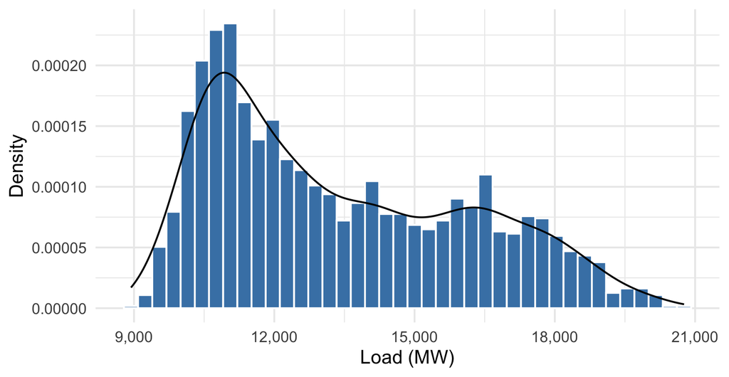

Daily mean electricity demand. The high-demand days in the right tail pull the mean above the median.

## Bimodal

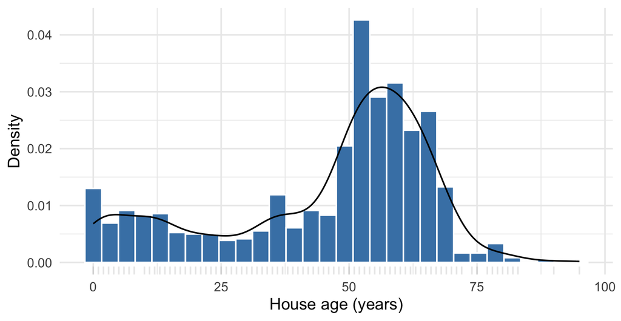

Austin house ages: newer construction on the left, the older building boom on the right. Two peaks often mean two subpopulations — investigate before summarizing with a single number.

## Anatomy of a box plot

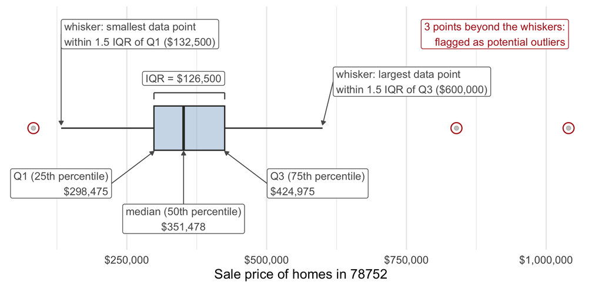

## Outliers

- Not everything extreme is an error: the $800K+ sales in 78752 are real, but a $13M listing in this dataset was a typo
- The 1.5 × IQR box-plot rule flags potential outliers; it is not a substitute for judgment

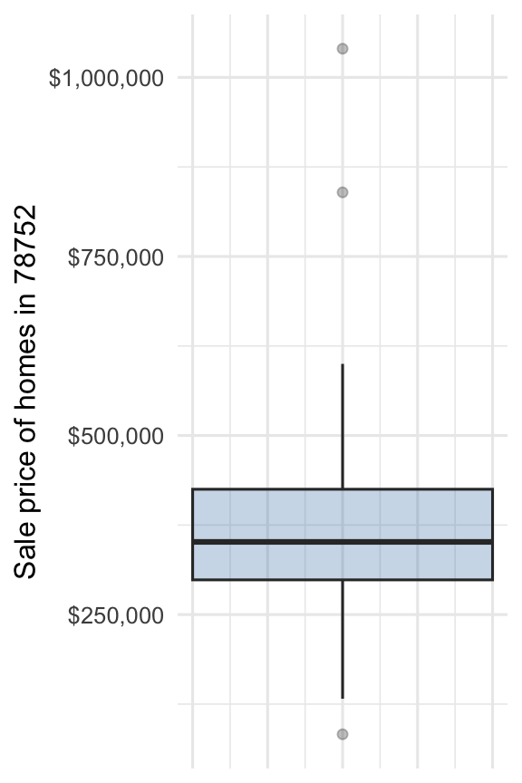